# Prediction of physical activity using machine learning

Marko Nikolic

Friday, October 23, 2015

# Introduction

This assignment attempts to predict the type of phisical activity using machine learning. Namely, we will try to predict if a certain type of workout (Unilateral Dumbbell Biceps Curl) is done in an appropriate manner using data collected from a series of human subjects who have performed the exercise while wearing belt, glove, arm-band and dumbbell sensors.

# Dataset

Dataset was provided on http://groupware.les.inf.puc-rio.br/har. The explanations and the paper produced after collecting the data by Velloso et al are also available on the web site. This dataset is licensed under the Creative Commons license (CC BY-SA).

The dataset consists of 19622 observations of 160 variables. The data has been collected from six individuals as a time series. The dataset contains acceleration, gyroscope and magnetometer readings along the x, y and z axis for all four sensor bearing devices (belt, glove, arm-band and dumbbell). In addition, roll, pitch and yaw on the Euler angles have been calculated as well as their mean, variance, standard deviation, max, min, amplitude, kurtosis and skewness.

The dependent variable, named classe, is a factor variable with 5 levels corresponding to five different ways the exercise can be performed:

- exactly according to the specification (Class A),
- throwing the elbows to the front (Class B),
- lifting the dumbbell only halfway (Class C),
- lowering the dumbbell only halfway (Class D) and
- throwing the hips to the front (Class E)

A separate dataset of 20 observations was provided for evaluation purposes.

# Dataset manipulation

It has been assumed the source data is in the working directory.

```r
### Preliminary actions
library(ggplot2); library(caret)
set.seed(696969)
train <- read.csv("./pml-training.csv")
test <- read.csv("./pml-testing.csv")

### Extraction of wanted variables

train_short <- cbind(train[,which(grepl("_x",names(train)))],
                     train[,which(grepl("_y",names(train))&!grepl("_ya",names(train)))  ],
                     train[,which(grepl("_z",names(train)))],
                     classe=train[,160])

### Split into new train and test set

inTrain = createDataPartition(train_short$classe, p=0.80, list=FALSE)
tts = train_short[inTrain,]
oob_test = train_short[-inTrain,]
inTrain = createDataPartition(train_short$classe, p=0.01, list=FALSE)
tts <- train_short[inTrain,]

all_oob <- matrix(data = NA, nrow = 3, ncol = 1, byrow = TRUE)
```

# Model selection

We have selected three machine learning algorithms as our initial models.

All the models were calculated using 5-fold cross validation.

```r
### Model selection
fitControl <- trainControl(method="repeatedcv", number=5, repeats=1, verboseIter=TRUE)

## Random Forest
set.seed(696969)
modFitForest <- train(classe~., method="rf",data=tts, trControl=fitControl, verbose=FALSE)
predict_oob <- predict(modFitForest,newdata=oob_test)
all_oob[1,1] <- 1-sum(predict_oob==oob_test$classe)/length(predict_oob)

## GBM
set.seed(696969)
gbmGrid <-  expand.grid(n.trees = 100, interaction.depth = 1,shrinkage = 0.1)
modFitGBM <- train(classe~., method="gbm",data=tts, trControl=fitControl, verbose=FALSE)
predict_oob <- predict(modFitGBM,newdata=oob_test)
all_oob[2,1] <- 1-sum(predict_oob==oob_test$classe)/length(predict_oob)

## SVM
set.seed(696969)
modFitSVM <- train(classe~., method="svmRadial",data=tts, trControl=fitControl, verbose=FALSE)
predict_oob <- predict(modFitSVM,newdata=oob_test)
all_oob[3,1] <- 1-sum(predict_oob==oob_test$classe)/length(predict_oob)
```

The results are summarized in the following charts:

```r
# collect resamples
results <- resamples(list(RF=modFitForest, GBM=modFitGBM, SVM=modFitSVM))
# summarize the distributions
summary(results)
```

```
##
## Call:
## summary.resamples(object = results)
##
## Models: RF, GBM, SVM
## Number of resamples: 5
##
## Accuracy
##       Min. 1st Qu. Median   Mean 3rd Qu.   Max. NA's
## RF  0.9841  0.9866 0.9866 0.9867  0.9879 0.9882    0
## GBM 0.9010  0.9013 0.9076 0.9064  0.9105 0.9114    0
## SVM 0.9051  0.9074 0.9099 0.9097  0.9114 0.9150    0
##
## Kappa
##       Min. 1st Qu. Median   Mean 3rd Qu.   Max. NA's
## RF  0.9799  0.9831 0.9831 0.9832  0.9847 0.9851    0
## GBM 0.8745  0.8749 0.8830 0.8814  0.8867 0.8878    0
## SVM 0.8797  0.8825 0.8857 0.8856  0.8877 0.8922    0
```

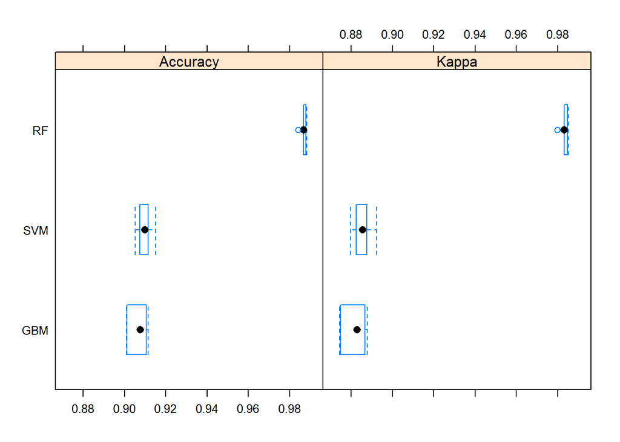

```r
# boxplots of results
bwplot(results)
```

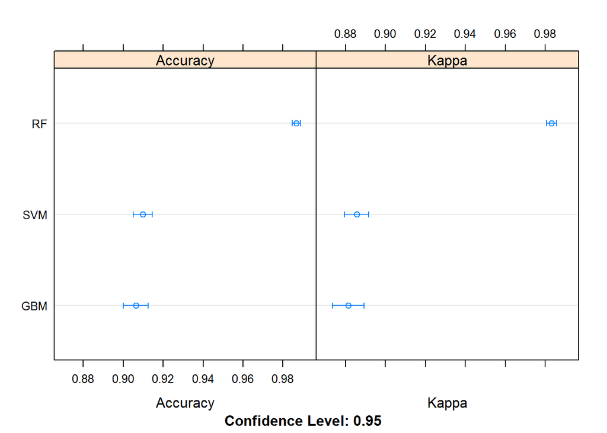

```r
# dot plots of results
dotplot(results)
```

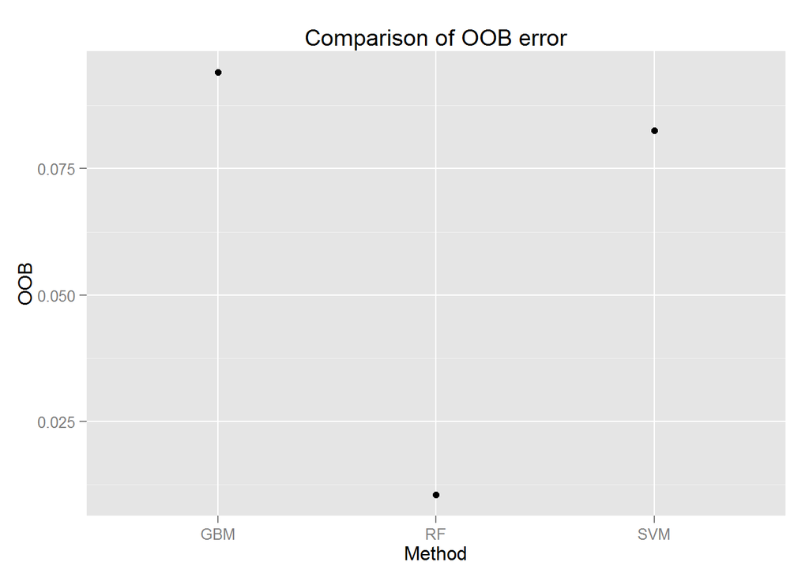

```r
dimnames(all_oob) <- list(c("RF","GBM","SVM"),c("OOB")) ; all_oob <- data.frame(all_oob)
qplot(rownames(all_oob),OOB, data=all_oob, xlab="Method", main="Comparison of OOB error")
```

# Final model

As the Random Forest has resulted in the highest accuracy and smallest OOB error, we decided to choose the Random Forest method as our final method and retrain it on the entire train set.

```r
set.seed(696969)
modFitFinal <- train(classe~., method="rf",data=train_short, trControl=fitControl, verbose=FALSE)
varImp(modFitFinal)
```

[output not shown]

# Application to the test set

Finally, we have applied our algorithm to the test set of 20 measurements. The test set was cleaned in the same way as the train set.

Our final prediction for the 20 test cases is the following:

```r
final_pred <- predict(modFitFinal,newdata=test_short); final_pred
```

```
##  [1] B A B A A E D B A A B C B A E E A B B B
## Levels: A B C D E
```